# Trabajo modulo 4 Big data

En este trabajo voy a usar un dataset de tumores cerebrales, extraído de kaggle. Sobre dicho dataset voy a realizar una clasificación.

```python
import numpy as np
import matplotlib.pyplot as plt
import pandas as pd
import seaborn as sns
from sklearn.metrics import accuracy_score, precision_score, recall_score, f1_score, roc_auc_score
from sklearn.metrics import r2_score, mean_squared_error, confusion_matrix, roc_curve, classification_report
from sklearn.model_selection import train_test_split, cross_val_score, GridSearchCV
from sklearn.preprocessing import LabelEncoder
from sklearn.linear_model import LogisticRegression
from sklearn.tree import DecisionTreeClassifier
from sklearn.ensemble import RandomForestClassifier,AdaBoostClassifier,BaggingClassifier,GradientBoostingClassifier
from sklearn.neighbors import KNeighborsClassifier
from sklearn.svm import SVC
from collections import Counter
from sklearn.metrics import r2_score
from sklearn import preprocessing
from sklearn.preprocessing import StandardScaler
from sklearn.naive_bayes import GaussianNB
```

```python
dat = pd.read_csv('data.csv')
dat
```

|  | Unnamed: 0 | X53416 | M83670 | X90908 | M97496 | X90908.1 | U37019 | R48602 | T96548 | X64559 | ... | H87456 | R64130 | H11125.1 | U22055 | L22524 | M13699.1 | X54489 | T55008 | M10065.2 | y |
| --- | --- | --- | --- | --- | --- | --- | --- | --- | --- | --- | --- | --- | --- | --- | --- | --- | --- | --- | --- | --- | --- |
| 0 | 0 | 70 | -81 | 25 | 10 | 22 | 113 | 36 | 163 | 9 | ... | 75 | 5 | 68 | 138 | 53 | -4 | 123 | 2 | 19 | tumor |
| 1 | 1 | 108 | -30 | -7 | 60 | 0 | 24 | 8 | 113 | -3 | ... | 186 | 6 | 60 | 93 | 140 | -3 | 271 | -1 | -51 | tumor |
| 2 | 2 | 75 | -1 | 5 | 48 | 6 | 34 | 27 | 35 | -1 | ... | 186 | 225 | 94 | 62 | 39 | -14 | 127 | 7 | 192 | tumor |
| 3 | 3 | 871 | 4 | 14 | 78 | -6 | 85 | 65 | 227 | 19 | ... | 77 | 6 | 78 | 30 | 87 | -4 | 59 | 3 | 367 | tumor |
| 4 | 4 | -92 | -34 | 14 | 19 | 11 | -6 | 27 | -8 | 9 | ... | 87 | 303 | 204 | 81 | 105 | 9 | 265 | -2 | 126 | tumor |
| 5 | 5 | 21 | -13 | 5 | 11 | -18 | 78 | 4 | 143 | 14 | ... | 51 | 3 | 131 | 38 | 10 | 4 | 3 | 9 | 145 | tumor |
| 6 | 6 | 225 | 118 | -5 | 175 | -40 | 108 | 54 | 272 | 32 | ... | 64 | -3 | 142 | 55 | 202 | -23 | 110 | 7 | -14 | tumor |
| 7 | 7 | -346 | -35 | 37 | 42 | 39 | 18 | 14 | 28 | 34 | ... | 84 | -5 | 13 | 102 | 27 | 17 | 30 | -5 | -53 | tumor |
| 8 | 8 | -378 | 31 | -29 | 105 | -54 | 19 | -4 | 11 | 16 | ... | 87 | -4 | 110 | 25 | 18 | 15 | 97 | 0 | -51 | tumor |
| 9 | 9 | 475 | -79 | 20 | 41 | 10 | 65 | -13 | 225 | 17 | ... | 115 | -4 | 95 | 47 | 41 | -4 | 76 | 11 | 22 | tumor |
| 10 | 10 | 133 | 45 | -11 | 72 | 5 | 45 | 34 | 175 | -2 | ... | 686 | 0 | 84 | 75 | 4 | -11 | 14 | 6 | 64 | tumor |
| 11 | 11 | -359 | -41 | -2 | 67 | 20 | 18 | 25 | 8 | -8 | ... | 66 | 6 | 67 | 59 | 27 | 1505 | 51 | -9 | -75 | tumor |
| 12 | 12 | 465 | -104 | 5 | 18 | 10 | 25 | 22 | 14 | 6 | ... | 53 | 686 | 10 | 62 | 444 | 13 | 131 | -5 | 267 | tumor |
| 13 | 13 | -694 | -45 | -34 | 66 | -11 | 28 | 19 | 97 | 12 | ... | 77 | 6 | 160 | 116 | 70 | 25 | 179 | -1 | -139 | tumor |
| 14 | 14 | -357 | 6 | 20 | 68 | 17 | 4 | -18 | 4 | 1 | ... | 20 | 12 | 251 | 54 | 125 | 3 | 52 | -1 | -72 | tumor |
| 15 | 15 | -343 | -38 | 28 | 45 | 36 | -1 | 37 | 17 | 2 | ... | 191 | -2 | 28 | 130 | 24 | -8 | 102 | 33 | -56 | tumor |
| 16 | 16 | -166 | -23 | 20 | 33 | -8 | 4 | -10 | -6 | -1 | ... | 58 | 4 | 28 | 70 | 6 | 11 | 87 | 2018 | 377 | tumor |
| 17 | 17 | 71 | -117 | -1 | 8 | 4 | 59 | 5 | 22 | 6 | ... | 58 | -4 | 57 | 75 | 4 | 6 | 114 | 1 | 1089 | tumor |
| 18 | 18 | 1314 | 320 | 2 | 1231 | 3 | 902 | 311 | 1249 | 259 | ... | -10 | 5 | 95 | 45 | 12 | 1 | 3 | -1 | 59 | Normal |
| 19 | 19 | 1815 | 172 | -9 | 700 | 5 | 1354 | 718 | 1327 | 161 | ... | -1 | 1 | 43 | 16 | -1 | -3 | 2 | 15 | -26 | Normal |
| 20 | 20 | 624 | 275 | -15 | 446 | 0 | 461 | 226 | 622 | 119 | ... | -24 | 22 | 96 | 28 | 4 | -1 | 16 | 2 | 173 | Normal |
| 21 | 21 | 462 | 379 | -21 | 1128 | 3 | 229 | 180 | 684 | 104 | ... | 17 | -3 | 94 | -4 | 8 | 0 | 10 | -5 | 66 | Normal |
| 22 | 22 | 672 | 549 | -11 | 1070 | 0 | 454 | 323 | 793 | 197 | ... | -3 | -1 | 30 | -9 | 2 | -7 | 7 | 5 | 81 | Normal |
| 23 | 23 | -107 | 127 | 14 | 491 | 25 | 76 | -5 | 460 | 75 | ... | 62 | 4 | 212 | 57 | 5 | 3 | -1 | 4 | -133 | Normal |
| 24 | 24 | 1079 | 463 | -14 | 1296 | -7 | 656 | 282 | 1536 | 148 | ... | 9 | 2 | 78 | -28 | -16 | 0 | -5 | 25 | -85 | Normal |
| 25 | 25 | -503 | 641 | -8 | 2261 | -27 | 130 | 25 | 395 | 63 | ... | 11 | 3 | 157 | -13 | 4 | -16 | 2 | -6 | -116 | Normal |
| 26 | 26 | 632 | 185 | 4723 | 1107 | 3344 | 1114 | 166 | 2100 | 72 | ... | 0 | -12 | 107 | -51 | 1 | -20 | 3 | -4 | -103 | Normal |
| 27 | 27 | 1412 | 288 | -21 | 731 | 8 | 673 | 298 | 1033 | 179 | ... | 9 | 6 | 101 | -73 | 6 | 1 | 8 | -5 | 39 | Normal |
| 28 | 28 | 1122 | 416 | -7 | 1559 | 5 | 836 | 376 | 1164 | 190 | ... | 120 | 5 | 22 | 25 | 0 | 9 | 16 | -17 | -10 | Normal |
| 29 | 29 | 644 | 625 | -28 | 1762 | -7 | 799 | 273 | 1599 | 98 | ... | 28 | 4 | 119 | -21 | 5 | -12 | 8 | 15 | -97 | Normal |
| 30 | 30 | 1760 | 320 | -8 | 917 | -2 | 1060 | 473 | 1472 | 226 | ... | 62 | 6 | 71 | 34 | 1 | -1 | 19 | -10 | -1 | Normal |
| 31 | 31 | 488 | 564 | -29 | 1303 | -9 | 1236 | 265 | 2203 | 41 | ... | 16 | 0 | 109 | 21 | 6 | -15 | 11 | 7 | -145 | Normal |
| 32 | 32 | 164 | 330 | -13 | 721 | 12 | 504 | 154 | 1381 | 78 | ... | -18 | 1 | -1484 | -4 | -1 | -1 | 3 | -5 | -63 | Normal |
| 33 | 33 | 1282 | 116 | -4 | 542 | 0 | 1070 | 344 | 1903 | 42 | ... | 5 | 3 | 128 | 25 | 2 | 0 | 7 | 3 | -69 | Normal |
| 34 | 34 | 68 | 718 | -50 | 1816 | -28 | 251 | 38 | 598 | 73 | ... | 47 | -2 | 190 | 3 | 0 | 8 | 21 | 22 | -214 | Normal |
| 35 | 35 | 928 | 332 | 4 | 412 | 0 | 681 | 267 | 1132 | 357 | ... | 9 | 1 | 67 | 19 | 10 | 1 | 32 | -5 | 72 | Normal |

36 rows × 7466 columns

Comprobar el tipo de cada dato para ver si debemos modificar alguno para hacer las operaciones que vamos a realizar.

```python
dat.dtypes
```

```
Unnamed: 0     int64
X53416         int64
M83670         int64
X90908         int64
M97496         int64
               ...
M13699.1       int64
X54489         int64
T55008         int64
M10065.2       int64
y             object
Length: 7466, dtype: object
```

```python
dat.head()
```

|  | Unnamed: 0 | X53416 | M83670 | X90908 | M97496 | X90908.1 | U37019 | R48602 | T96548 | X64559 | ... | H87456 | R64130 | H11125.1 | U22055 | L22524 | M13699.1 | X54489 | T55008 | M10065.2 | y |
| --- | --- | --- | --- | --- | --- | --- | --- | --- | --- | --- | --- | --- | --- | --- | --- | --- | --- | --- | --- | --- | --- |
| 0 | 0 | 70 | -81 | 25 | 10 | 22 | 113 | 36 | 163 | 9 | ... | 75 | 5 | 68 | 138 | 53 | -4 | 123 | 2 | 19 | tumor |
| 1 | 1 | 108 | -30 | -7 | 60 | 0 | 24 | 8 | 113 | -3 | ... | 186 | 6 | 60 | 93 | 140 | -3 | 271 | -1 | -51 | tumor |
| 2 | 2 | 75 | -1 | 5 | 48 | 6 | 34 | 27 | 35 | -1 | ... | 186 | 225 | 94 | 62 | 39 | -14 | 127 | 7 | 192 | tumor |
| 3 | 3 | 871 | 4 | 14 | 78 | -6 | 85 | 65 | 227 | 19 | ... | 77 | 6 | 78 | 30 | 87 | -4 | 59 | 3 | 367 | tumor |
| 4 | 4 | -92 | -34 | 14 | 19 | 11 | -6 | 27 | -8 | 9 | ... | 87 | 303 | 204 | 81 | 105 | 9 | 265 | -2 | 126 | tumor |

5 rows × 7466 columns

Ver si existen valores nulos en nuestro dataset.

```python
dat.isnull().sum()
```

```
Unnamed: 0    0
X53416        0
M83670        0
X90908        0
M97496        0
             ..
M13699.1      0
X54489        0
T55008        0
M10065.2      0
y             0
Length: 7466, dtype: int64
```

```python
dat.info()
```

```
<class 'pandas.core.frame.DataFrame'>
RangeIndex: 36 entries, 0 to 35
Columns: 7466 entries, Unnamed: 0 to y
dtypes: int64(7465), object(1)
memory usage: 2.1+ MB
```

Una vez visto que no hay valores nulos empezamos a preparar las columnas para trabajar con ellas. Primero eliminaremos la columna Unnamed, ya que no la vamos a necesitar.

```python
dat.drop(columns=['Unnamed: 0'],axis=1,inplace=True)
```

Observamos que nos queda una columna "y" que contiene strings, así que la vamos a tratar para convertirla en valores.

```python
t= preprocessing.LabelEncoder()
dat['y']= t.fit_transform(dat['y'])
```

```python
dat['y']
```

```
0     1
1     1
2     1
3     1
4     1
5     1
6     1
7     1
8     1
9     1
10    1
11    1
12    1
13    1
14    1
```

[output cut: 22 more lines]

```python
y = dat["y"]
X = dat.drop(["y"],axis = 1)
```

```python
X_train, X_test, y_train, y_test = train_test_split(X,y,test_size = 0.4)
```

```python
print(X_train)
print(y_train)
```

```
    X53416  M83670  X90908  M97496  X90908.1  U37019  R48602  T96548  X64559  \
28    1122     416      -7    1559         5     836     376    1164     190
15    -343     -38      28      45        36      -1      37      17       2
10     133      45     -11      72         5      45      34     175      -2
3      871       4      14      78        -6      85      65     227      19
34      68     718     -50    1816       -28     251      38     598      73
27    1412     288     -21     731         8     673     298    1033     179
8     -378      31     -29     105       -54      19      -4      11      16
11    -359     -41      -2      67        20      18      25       8      -8
14    -357       6      20      68        17       4     -18       4       1
6      225     118      -5     175       -40     108      54     272      32
20     624     275     -15     446         0     461     226     622     119
32     164     330     -13     721        12     504     154    1381      78
5       21     -13       5      11       -18      78       4     143      14
24    1079     463     -14    1296        -7     656     282    1536     148
```

[output cut: 77 more lines]

Creamos la tabla Comparación para poder comparar las métricas de rendimiento de forma más sencilla al final.

```python
Comparacion = {'Modelo':[],'precisión':[],'exactitud':[],'exhaustividad':[],'F1':[]}
```

# Ahora empezaremos con las distintas tareas de clasificación, de las cuales la primera sera la Regresión logística

```python
sc = StandardScaler()
X_train= sc.fit_transform(X_train)
X_test = sc.transform(X_test)
print(X_train)
print(X_test)
```

```
[[ 1.40316138  0.97561963 -0.22501105 ... -0.47405392 -1.92027743
  -0.10895977]
 [-1.2403328  -1.03422427 -0.1902594  ...  0.88490065  2.59044136
  -0.4518104 ]
 [-0.38142274 -0.66678585 -0.22898267 ... -0.50565751  0.15465322
   0.44258254]
 ...
 [ 0.25915093  1.63081104 -0.24685495 ... -0.5530629   0.24486759
  -1.11515183]
 [ 0.59116658  1.56440651 -0.22898267 ... -0.61627009  0.06443884
   0.5692882 ]
 [ 1.69187064 -0.35247105 -0.22203234 ... -0.61627009 -0.11598991
  -0.54870297]]
[[ -1.87368874  -1.06521305  -0.25181947 ...   2.10163904  -0.47684741
   -1.07043218]
 [ -0.49329758  -1.38395482  -0.21905363 ...   1.07452221  -0.29641866
    8.08218889]
 [  1.7496125    0.55063061  -0.21607491 ...  -0.67947728  -0.47684741
    0.40531617]
 ...
 [  0.54064246   1.90085615  -0.24586204 ...  -0.6004683    0.9665826
   -0.75739466]
 [  0.21223568   0.81182178  -0.23891171 ...  -0.5688647   -0.83770492
    0.45748909]
 [ -0.92094817  -0.96781974  -0.19820263 ...   0.64787369 181.66597726
    2.77545745]]
```

```python
X_train1=X_train.copy()
X_test1=X_test.copy()
```

```python
log_reg=LogisticRegression(random_state=0,max_iter=900)
```

```python
log_reg.fit(X_train1,y_train)
```

```
LogisticRegression(max_iter=900, random_state=0)
```

```python
log_reg.score(X_test1,y_test)
```

```
1.0
```

```python
y_pred = log_reg.predict(X_test1)
```

```python
print('accuracy=', accuracy_score(y_test, y_pred))
print('precision=', precision_score(y_test, y_pred))
print('recall=', recall_score(y_test, y_pred))
print('F1 Score=', f1_score(y_test, y_pred))
```

```
accuracy= 1.0
precision= 1.0
recall= 1.0
F1 Score= 1.0
```

```python
Comparacion['Modelo'].append("log_reg")
Comparacion['precisión'].append(accuracy_score(y_test, y_pred))
Comparacion['exactitud'].append(precision_score(y_test, y_pred))
Comparacion['exhaustividad'].append(recall_score(y_test, y_pred))
Comparacion['F1'].append(f1_score(y_test, y_pred))
```

# K-Nearest Neighbors

```python
X_train2=X_train.copy()
X_test2=X_test.copy()
```

```python
knn = KNeighborsClassifier(n_neighbors = 2).fit(X_train2,y_train)
knn.score(X_test2,y_test)
```

```
0.8
```

```python
y_pred = knn.predict(X_test2)
```

```python
print('accuracy=', accuracy_score(y_test, y_pred))
print('precision=', precision_score(y_test, y_pred))
print('recall=', recall_score(y_test, y_pred))
print('F1 Score=', f1_score(y_test, y_pred))
```

```
accuracy= 0.8
precision= 1.0
recall= 0.625
F1 Score= 0.7692307692307693
```

```python
Comparacion['Modelo'].append("knn")
Comparacion['precisión'].append(accuracy_score(y_test, y_pred))
Comparacion['exactitud'].append(precision_score(y_test, y_pred))
Comparacion['exhaustividad'].append(recall_score(y_test, y_pred))
Comparacion['F1'].append(f1_score(y_test, y_pred))
```

# Decision Tree

```python
X_train3=X_train.copy()
X_test3=X_test.copy()
```

```python
tree = DecisionTreeClassifier(random_state = 0).fit(X_train3,y_train)
tree.score(X_test3,y_test)
```

```
1.0
```

```python
y_pred = tree.predict(X_test3)
```

```python
print('accuracy=', accuracy_score(y_test, y_pred))
print('precision=', precision_score(y_test, y_pred))
print('recall=', recall_score(y_test, y_pred))
print('F1 Score=', f1_score(y_test, y_pred))
```

```
accuracy= 1.0
precision= 1.0
recall= 1.0
F1 Score= 1.0
```

```python
Comparacion['Modelo'].append("tree")
Comparacion['precisión'].append(accuracy_score(y_test, y_pred))
Comparacion['exactitud'].append(precision_score(y_test, y_pred))
Comparacion['exhaustividad'].append(recall_score(y_test, y_pred))
Comparacion['F1'].append(f1_score(y_test, y_pred))
```

# Random Forest

```python
X_train4=X_train.copy()
X_test4=X_test.copy()
```

```python
rf = RandomForestClassifier(random_state = 0).fit(X_train4,y_train)
rf.score(X_test4,y_test)
```

```
1.0
```

```python
y_pred = rf.predict(X_test4)
```

```python
print('accuracy=', accuracy_score(y_test, y_pred))
print('precision=', precision_score(y_test, y_pred))
print('recall=', recall_score(y_test, y_pred))
print('F1 Score=', f1_score(y_test, y_pred))
```

```
accuracy= 1.0
precision= 1.0
recall= 1.0
F1 Score= 1.0
```

```python
Comparacion['Modelo'].append("rf")
Comparacion['precisión'].append(accuracy_score(y_test, y_pred))
Comparacion['exactitud'].append(precision_score(y_test, y_pred))
Comparacion['exhaustividad'].append(recall_score(y_test, y_pred))
Comparacion['F1'].append(f1_score(y_test, y_pred))
```

# Naive bayes

```python
X_train5=X_train.copy()
X_test5=X_test.copy()
```

```python
nb= GaussianNB()
nb.fit(X_train5,y_train)
nb.score(X_test5,y_test)
```

```
0.9333333333333333
```

```python
y_pred = nb.predict(X_test5)
```

```python
print('accuracy=', accuracy_score(y_test, y_pred))
print('precision=', precision_score(y_test, y_pred))
print('recall=', recall_score(y_test, y_pred))
print('F1 Score=', f1_score(y_test, y_pred))
```

```
accuracy= 0.9333333333333333
precision= 1.0
recall= 0.875
F1 Score= 0.9333333333333333
```

```python
Comparacion['Modelo'].append("nb")
Comparacion['precisión'].append(accuracy_score(y_test, y_pred))
Comparacion['exactitud'].append(precision_score(y_test, y_pred))
Comparacion['exhaustividad'].append(recall_score(y_test, y_pred))
Comparacion['F1'].append(f1_score(y_test, y_pred))
```

# Bagging

```python
X_train6=X_train.copy()
X_test6=X_test.copy()
```

```python
bag = BaggingClassifier(random_state = 0).fit(X_train6,y_train)
bag.score(X_test6,y_test)
```

```
0.8666666666666667
```

```python
y_pred = bag.predict(X_test6)
```

```python
print('accuracy=', accuracy_score(y_test, y_pred))
print('precision=', precision_score(y_test, y_pred))
print('recall=', recall_score(y_test, y_pred))
print('F1 Score=', f1_score(y_test, y_pred))
```

```
accuracy= 0.8666666666666667
precision= 1.0
recall= 0.75
F1 Score= 0.8571428571428571
```

```python
Comparacion['Modelo'].append("bag")
Comparacion['precisión'].append(accuracy_score(y_test, y_pred))
Comparacion['exactitud'].append(precision_score(y_test, y_pred))
Comparacion['exhaustividad'].append(recall_score(y_test, y_pred))
Comparacion['F1'].append(f1_score(y_test, y_pred))
```

# Comparación

```
Score :  1.0
```

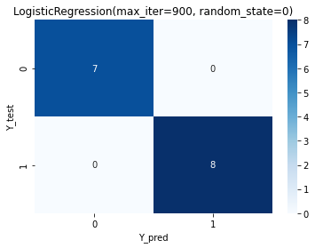

```
Score :  0.8
```

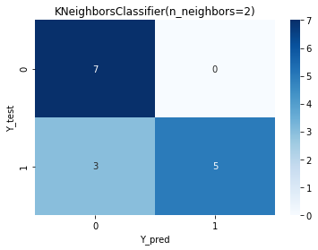

```
Score :  1.0
```

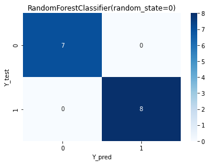

```
Score :  1.0
```

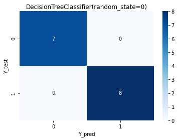

```
Score :  0.9333333333333333
```

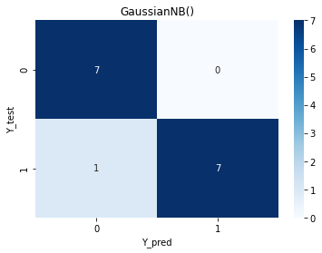

```
Score :  0.8666666666666667
```

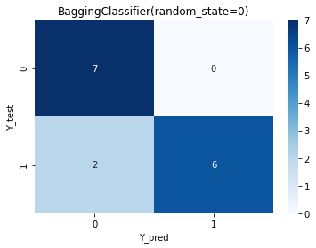

```python
pred_list = [log_reg,knn,rf,tree,nb,bag]

for i in pred_list:
    print("Score : ",i.score(X_test,y_test))
    y_pred = i.predict(X_test)
    sns.heatmap(confusion_matrix(y_test,y_pred),annot = True,cmap='Blues')
    plt.xlabel("Y_pred")
    plt.ylabel("Y_test")
    plt.title(i)
    plt.show()
```

```python
comparación= pd.DataFrame.from_dict(Comparacion)
comparación
```

|  | Modelo | precisión | exactitud | exhaustividad | F1 |
| --- | --- | --- | --- | --- | --- |
| 0 | log_reg | 1.000000 | 1.0 | 1.000 | 1.000000 |
| 1 | knn | 0.800000 | 1.0 | 0.625 | 0.769231 |
| 2 | tree | 1.000000 | 1.0 | 1.000 | 1.000000 |
| 3 | rf | 1.000000 | 1.0 | 1.000 | 1.000000 |
| 4 | nb | 0.933333 | 1.0 | 0.875 | 0.933333 |
| 5 | bag | 0.866667 | 1.0 | 0.750 | 0.857143 |

Podemos observar que lo más probable es que estos datos ya hubieran sido tratados con anterioridad, puesto que tiene un ajuste demasiado exacto a los modelos, puesto que dependiendo el random_state que escojamos nos puede dar un modelo perfecto, de ahí que no se escoja uno determinado y que sea aleatorio cada vez, para ver los cambios en las métricas de rendimiento con los distintos modelos de clasificación.